# Time Series Homework: Chapter 4 Lesson 1 Key

## Questions

### Question 1 - Gaussian White Noise (30 points)

#### a) Simulate a realization of Gaussian White Noise and plot it. Use 50 points and $\sigma^2=2$

**Answer**

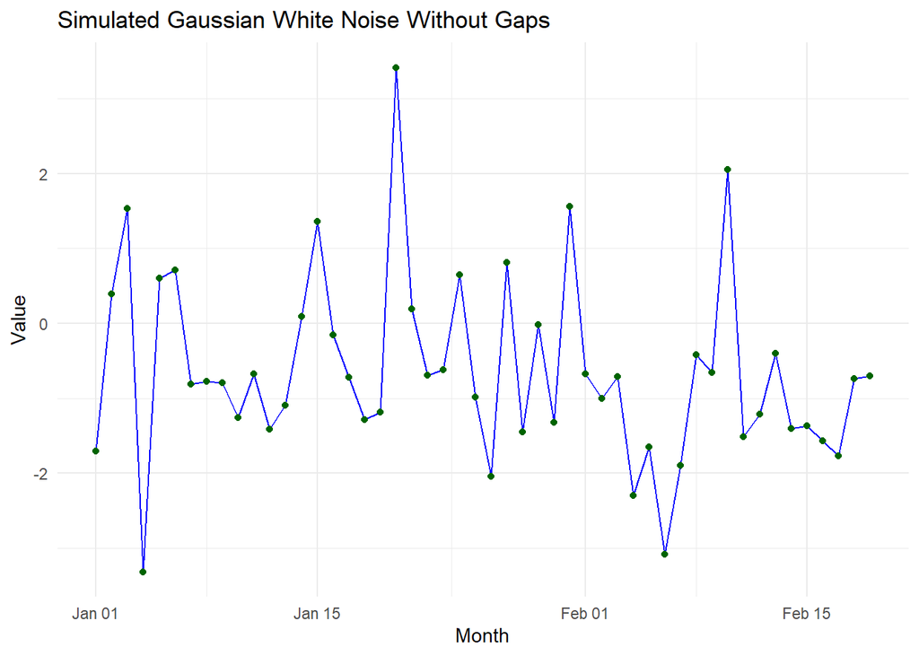

```r
set.seed(1234)

# 1. Simulate 50 observations from N(0, 2)
mu <- 0
sigma_squared <- 2
n <- 50

# Generate white noise data
data <- rnorm(n, mean = mu, sd = sqrt(sigma_squared))

# 2. Create a Time Series Object with Weekly Seasonality (frequency = 7)
# Assuming the data is daily, a frequency of 7 captures weekly patterns
ts_data <- ts(data, frequency = 7)

# 3. Convert the ts Object to a tsibble
# The 'as_tsibble()' function automatically handles the frequency
tsibble_data <- as_tsibble(ts_data)

# Plot the Gaussian White Noise
ggplot(tsibble_data, aes(x = index, y = value)) +
  geom_line(color = "blue") +
  geom_point(color = "darkgreen") +
  labs(
    title = "Simulated Gaussian White Noise Without Gaps",
    x = "Month",
    y = "Value"
  ) +
  theme_minimal()
```

#### b) Estimate the mean and variance. Why don’t they match exactly with the parameters values you used to create it?

**Answer**

```r
sample_mean <- mean(tsibble_data$value)
print(paste("Sample Mean:", round(sample_mean, 4)))
```

```
[1] "Sample Mean: -0.6407"
```

```r
sample_variance <- var(tsibble_data$value)
print(paste("Sample Variance:", round(sample_variance, 4)))
```

```
[1] "Sample Variance: 1.5666"
```

The reason the mean, variance, and covariance don’t match exactly with the parameters we used, is because this is data taken from a population. Because it is a sample it won’t catch 100% exactly what is going on because there wasn’t a high enough number of observations taken as a sample and there is a random component of variability within the sample.

**Answer**

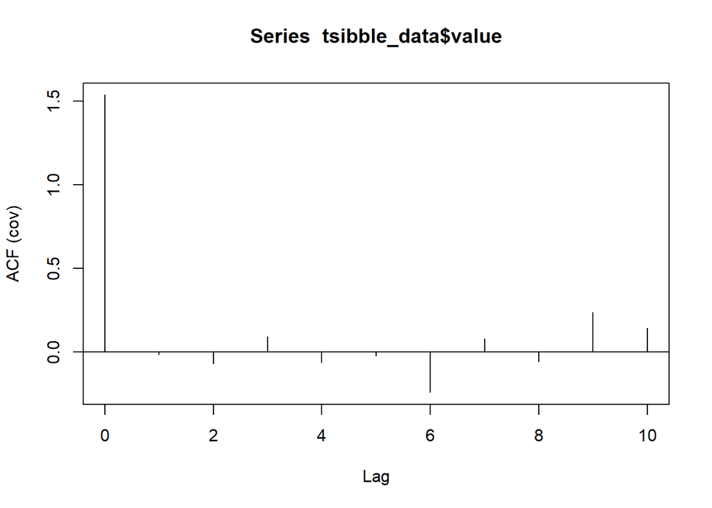

```r
acf(tsibble_data$value, plot=TRUE, type = "covariance", lag = 10)
```

#### d) Use the classical decomposition on your simulated series, plot the results.

**Answer**

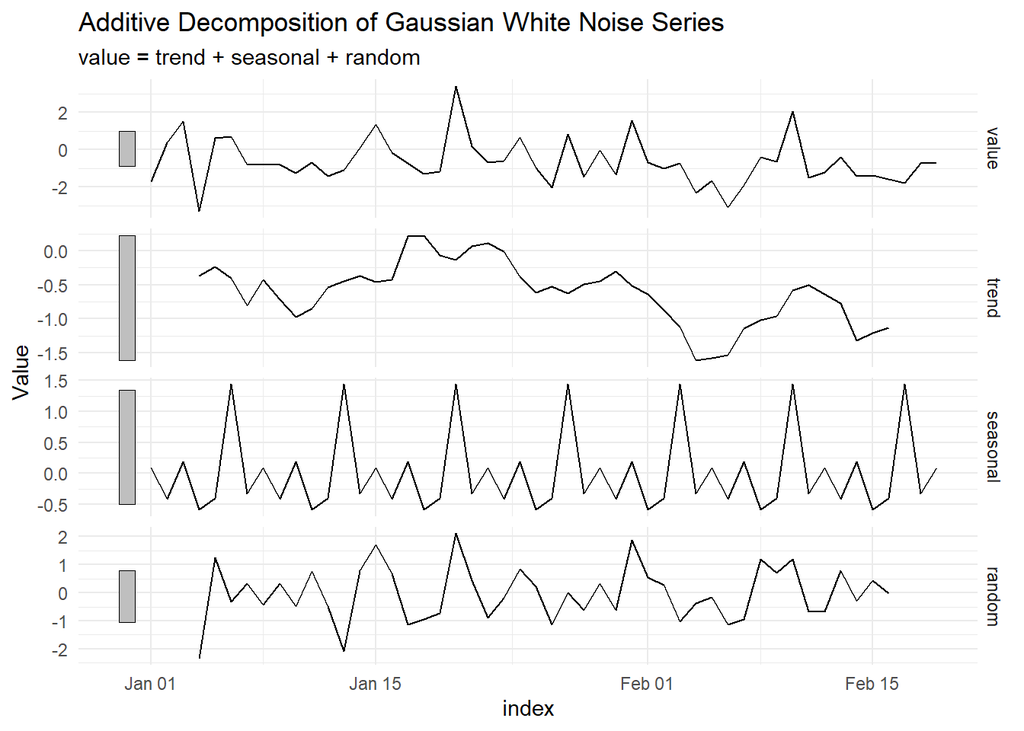

```r
decomp <- tsibble_data %>%
  model(
    classical_decomposition(type = "additive")
  ) %>%
  components()

# 5. Plot the Decomposed Components
autoplot(decomp) +
  labs(
    title = "Additive Decomposition of Gaussian White Noise Series",
    y = "Value"
  ) +
  theme_minimal()
```

#### d) Please evaluate practical signifficance of the estimates of the trend and seasonal component.

**Answer**

Given this is a Gaussian white noise simulated data frame, the data is stochastic. The mean is 0 so there is no trend. The theoretical autocorrelation is 0 so there is no seasonality. The algorithm will estimate something … We know that even though there is a trend component, it’s average should focus around 0 since that is the distribution it came from. The decomposition algorithm assumes some underlying trend in the data even though none exists. Random noise gets misinterpreted as small-scale trends due to the smooth process used to estimate the trend.

While Gaussian white noise ought to have no periodic or seasonal patterns, the algorithm seems to believe there is a seasonal component. This is from the decomposition trying to impose a seasonal structure on inherently random data. A seasonal pattern here is visible because it is an artifact of the decomposition algorithm.

Because this data is random, the random component should resemble the original data, as all randomness here is captured after substracting the trend and seasonal component, however, we see here the random component looks quite different because the algorithm creating a seasonal and trend component.

## Extra Credit

### Question 3 - Random Walks (55 points)

#### a) Simulate a realization of a white noise process using the Exponential distribution. If $s_t$ is the realization from an exponentially distributed random variable, use the white noise $w_t=s_t-\lambda$ for your simulation. The length of the series is 500 points and $\lambda=1$. Please plot your simulation.

**Answer**

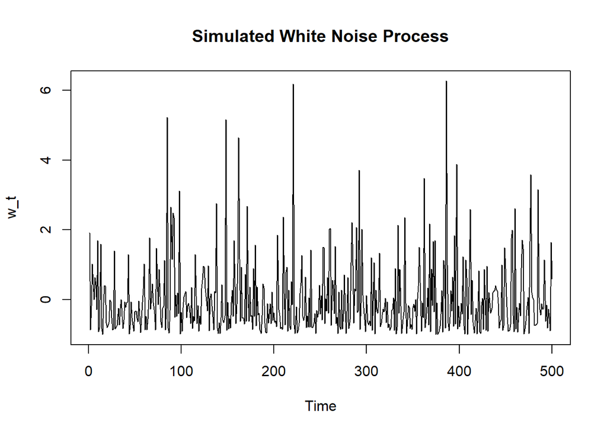

```r
# Set parameters
lambda <- 1
n <- 500


s_t <- rexp(n, rate = lambda)  # exponential random variable with rate lambda
w_t <- s_t - lambda  # white noise process

# Plot the white noise series
plot(w_t, type = "l", main = "Simulated White Noise Process", ylab = "w_t", xlab = "Time")
```

[output not shown]

**Answer**

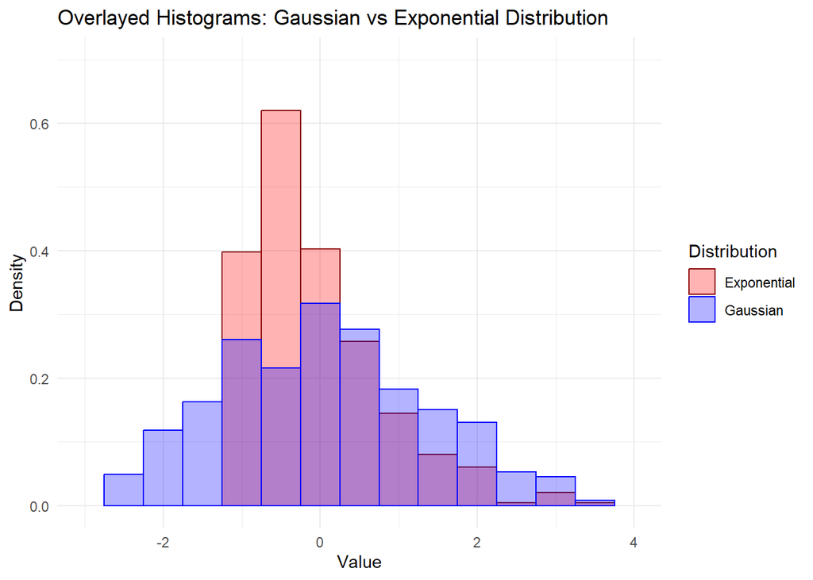

```r
# Exponential White Noise Parameters
lambda <- 1
n_exp <- 500
s_t <- rexp(n_exp, rate = lambda)
w_t_exp <- s_t - lambda  # Centered Exponential White Noise

# Gaussian White Noise Parameters
n_gauss <- 500
sigma2 <- 2
sigma <- sqrt(sigma2)

w_t_gauss <- rnorm(n_gauss, mean = 0, sd = sigma)




df <- data.frame(
  value = c(w_t_exp, w_t_gauss),
  dist = factor(rep(c("Exponential", "Gaussian"),
                    times = c(length(w_t_exp), length(w_t_gauss))))
)

ggplot(df, aes(x = value, fill = dist, color = dist)) +
  geom_histogram(aes(y = ..density..), position = "identity", bins = 15, alpha = 0.3) +
  scale_fill_manual(values = c("Exponential" = rgb(1, 0, 0, 0.3),
                               "Gaussian" = rgb(0, 0, 1, 0.3))) +
  scale_color_manual(values = c("Exponential" = "darkred",
                                "Gaussian" = "blue")) +
  labs(title = "Overlayed Histograms: Gaussian vs Exponential Distribution",
       x = "Value", y = "Density",
       fill = "Distribution", color = "Distribution") +
  xlim(c(-3, 4)) + ylim(c(0, 0.7)) +
  theme_minimal()
```

#### c) Create a random walk series using the Exponential DWN simulations. Please plot the series.

**Answer**

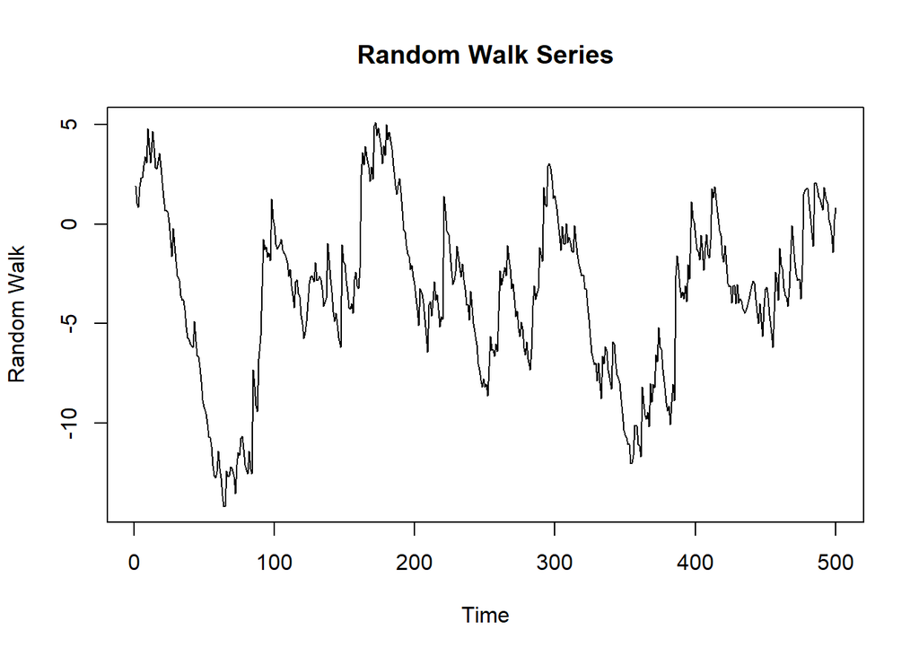

```r
# Generate the random walk series by taking the cumulative sum of w_t
random_walk <- cumsum(w_t)

# Plot the random walk series
plot(random_walk, type = "l", main = "Random Walk Series", ylab = "Random Walk", xlab = "Time")
```

#### d) Use the Holt-Winters decomposition method to estimate the trend, seasonal, and random components of the series.

**Answer**

```r
random_walk_ts <- ts(random_walk, frequency = 12) %>% as_tsibble()


hw_model <- random_walk_ts %>%
  model(
    Additive = ETS(
      value ~ error("A") + trend("A") + season("A"),
      opt_crit = "amse",
      nmse = 1
    )
  )

report(hw_model)
```

```
Series: value
Model: ETS(A,A,A)
  Smoothing parameters:
    alpha = 0.9503298
    beta  = 0.0001031695
    gamma = 0.02856599

  Initial states:
     l[0]       b[0]       s[0]      s[-1]      s[-2]       s[-3]       s[-4]
 2.477575 -0.0102033 -0.1772354 -0.1363246 0.02429963 -0.03235896 -0.05994879
      s[-5]     s[-6]      s[-7]     s[-8]      s[-9]     s[-10]    s[-11]
 0.05676777 0.3267906 -0.2972415 0.1992056 -0.1795977 0.03721112 0.2384321

  sigma^2:  1.171

     AIC     AICc      BIC
3203.978 3205.248 3275.626
```

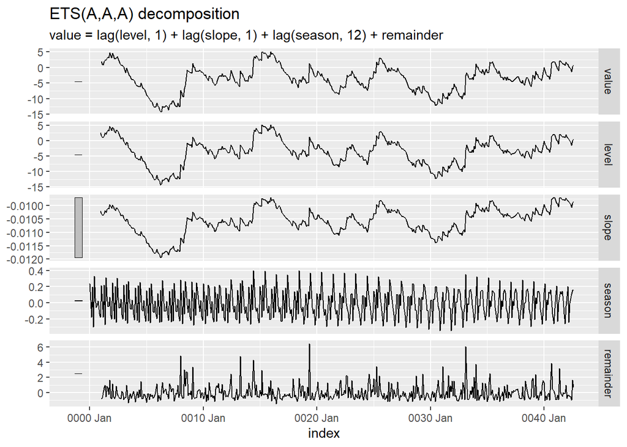

```r
autoplot(components(hw_model))
```

#### e) Please evaluate practical significance of the estimates for the parameters of the model using the default algorithm settings (minimize the SS1PE).

**Answer**

The estimated Holt-Winters parameters, with $\alpha$ at 0.95, $\beta$ at 0.0001, and $\gamma$ at 0.03, are highly sensible for a random walk series generated from exponential discrete white noise. The high $\alpha$ value indicates that the model heavily weights the most recent observation to update the level, which is characteristic of a random walk where the best forecast for the next period is closely tied to the current value. The extremely low $\beta$ and $\gamma$ values, both near zero, correctly reflect the inherent nature of a random walk: it lacks a persistent, deterministic trend (even if there’s drift, it’s captured by the level) and exhibits no seasonality. Essentially, these parameters show the Holt-Winters model adapting appropriately by simplifying itself. It has effectively recognized the absence of strong trend and seasonal patterns, leading to a model that behaves very much like a highly adaptive simple exponential smoothing. You may see different values as you estimate, expect values between the following: $\alpha$ between 0.94 and 0.99, $\beta$ at between 0.03 and 0.0001, and $\gamma$ between 0.03 and 0.0001.

### Rubric

[output not shown]